# Healthy Plate Builder

This project is designed to promote healthier, yet tasty, eating habits. In the U.S., unhealthy food options are widespread, with many daily meals consisting of fast and overprocessed foods. These choices often lack the nutritional value needed for a balanced diet. This program aims to help guide individuals toward better food decisions by offering a more nutritious alternative.

## About this project

Using data from the USDA food database, the goal is to create an interactive plate builder that allows users to build their own meal from a variety of nutritious options—including fruits, vegetables, protein, dairy, and carbohydrates. Once the plate is complete, the program will provide a nutritional analysis, showing how balanced the meal is and offering insights into its health value.

### Part 1: Importing, Cleaning, and Organizing Data

The goal of this section is to complete a few key steps: 1.Succesfully import the data we'd like to use 2. Clean our data 3. Have our data ready for use in the following parts.

The data used comes from the FoodData Central of the USDA. Definitions for the terms and labels used in our chosen dataset is here

The dataset comes from the FoodData Central provided by the USDA. Definitions for the terms and labels used in the selected dataset are available through the source.

CSV files were downloaded directly from the USDA Food Central Data site. Out of the 25 available files, 4 were selected to serve as the foundation of the project.

During the cleaning and organizing process, the selected CSV files were merged. Key information was retained, including food descriptions, food type, and macronutrient data such as calories, protein, fats, and carbohydrates for each item.

### Part 2: Design our Interactive Aspects

This section focuses on designing how user input will function within the program.

The interactive component allows users to build their own plate by adding food items one at a time. The program stops recording items when the user types “stop.” Users also have the option to save their plate by creating a username and password.

In the main execution of the program, users are prompted to respond to a few yes/no and create/retrieve prompts, which determine how the program proceeds.

### Part 3: Nutritional Analysis

This part focuses on translating user input into meaningful nutritional details.

Nutritional analysis is presented visually. Based on the foods added to a user’s plate, the program calculates the total amount of each nutrient and compares it against the FDA’s recommended daily values: 2000 kcal , Protein: 50 g, Carbohydrates: 275 g, Fats: 78 g. We then display what percentage of a users plate in relation to the daily nutritional values from 0% to 100%.

### Part 4: Visualization

This section focuses on clearly presenting the results of the nutritional data and user input.

An additional visualization displays what the user’s plate looks like in terms of food groups, based on the items entered.

### Part 5: Healthy Plate Builder in Action

This is the final section, where users are able to actively use the interactive plate builder to explore and create balanced meals.

## Ex1.

### Plate: broccoli, cabbage, beef, marshmallow, sneakers, chicken, rice, orange

### Username:sample2 Password:sample2

```
Welcome to the Healthy Plate Builder!
```

```
Invalid input. Please type 'create' or 'retrieve'.
```

```
Invalid input. Please type 'create' or 'retrieve'.
```

```
Add foods to your plate. Type 'stop' when you're done.
```

```
Added 'broccoli' to your plate.
```

```
Added 'cabbage' to your plate.
```

```
Added 'beef' to your plate.
```

```
Added 'marshmellow' to your plate.
```

```
Added 'sneakers' to your plate.
```

```
Added 'chicken' to your plate.
```

```
Added 'rice' to your plate.
```

```
Added 'orange' to your plate.
```

```
Plate saved for user 'sample2'!
Food 'cabbage' not found in USDA data.
Food 'marshmellow' not found in USDA data.
Food 'sneakers' not found in USDA data.
```

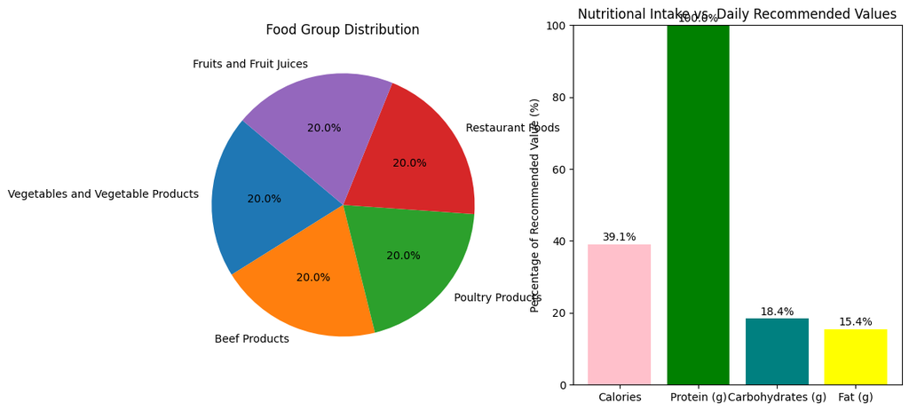

```python
# importing all the necessary libraries, collections, and our scripts.py

import sys
from scripts import (
    load_and_prepare_data,
    save_plate,
    retrieve_plate,
    get_nutritional_data,
    visualize_plate
)
import os

#loading our data and prepping for saved plates
foundationfood = load_and_prepare_data()
user_data_file = os.path.join("Data", "user_plates.json")

# the point of execution for our project

def main():
    print("Welcome to the Healthy Plate Builder!\n")

    # Choose to create or retrieve a plate
    while True:
        choice = input("Would you like to create a new plate or retrieve a saved plate? (create/retrieve): ").strip().lower()
        if choice in ["create", "retrieve"]:
            break
        else:
            print("Invalid input. Please type 'create' or 'retrieve'.")

    # Create a new plate
    if choice == "create":
        plate = []
        print("\nAdd foods to your plate. Type 'stop' when you're done.\n")
        while True:
            food_item = input("Enter a food to add: ").strip()
            if food_item.lower() == "stop":
                break
            elif food_item:
                plate.append(food_item)
                print(f"Added '{food_item}' to your plate.")
            else:
                print("Invalid input. Try again.")

        if input("\nDo you want to save your plate? (yes/no): ").strip().lower() == "yes":
            username = input("Enter a username: ").strip()
            password = input("Enter a password: ").strip()
            save_plate(username, password, plate, user_data_file)

    # Retrieve a saved plate
    else:
        username = input("\nEnter your username: ").strip()
        password = input("Enter your password: ").strip()
        plate = retrieve_plate(username, password, user_data_file)

    if plate:
        nutritional_data = get_nutritional_data(plate, foundationfood)
        if nutritional_data:
            if input("\nView visualizations? (yes/no): ").strip().lower() == "yes":
                visualize_plate(plate, nutritional_data)
        else:
            print("No nutritional data found.")

if __name__ == "__main__":
    main()
```

## Ex 2 Plate: cheese, lettuce, tomato, apple

### Username:sample3 Password:sample3

```
Welcome to the Healthy Plate Builder!
```

```
Add foods to your plate. Type 'stop' when you're done.
```

```
Added 'cheese' to your plate.
```

```
Added 'lettuce' to your plate.
```

```
Added 'tomato' to your plate.
```

```
Added 'apple' to your plate.
```

```
Plate saved for user 'sample3'!
```

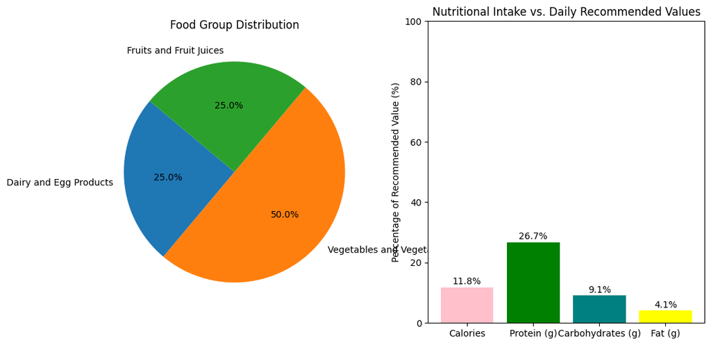

```python
if __name__ == "__main__":
    main()
```

## Ex 3

### Plate: plum, radish, pork, noodle, ketchup

### No visualizations

```python
if __name__ == "__main__":
    main()
```

```
Welcome to the Healthy Plate Builder!
```

```
Invalid input. Please type 'create' or 'retrieve'.
```

```
Add foods to your plate. Type 'stop' when you're done.
```

```
Added 'plum' to your plate.
```

```
Added 'radish' to your plate.
```

```
Added 'pork' to your plate.
```

```
Added 'noodle' to your plate.
```

```
Added 'ketchup' to your plate.
```

```
Food 'plum' not found in USDA data.
Food 'radish' not found in USDA data.
Food 'noodle' not found in USDA data.
```

## Ex 4 showing relation to Ex1

### Username:sample2 Password:sample2

```
Welcome to the Healthy Plate Builder!
```

[output not shown]

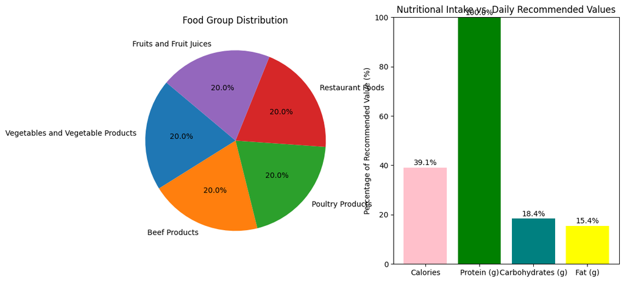

```python
if __name__ == "__main__":
    main()
```